# Praca domowa 7

Michał Pastuszka

10 - 06 - 2019

# 1 Wstęp

Będziemy porównywać algorytmy k średnich i k medioidów na zbiorze danych iris. Wykorzystamy implementacje `kmeans` z pakietu `stats` i `fastkmed` z pakietu `kmed`.

# 2 Optymalne liczby klastrów

Do wyznaczenia optymalnej liczby klastrów wykorzystamy statystyki within.cluster.ss, dunn2, pearsongamma i avg.silwidth z pakietu `fpc`.

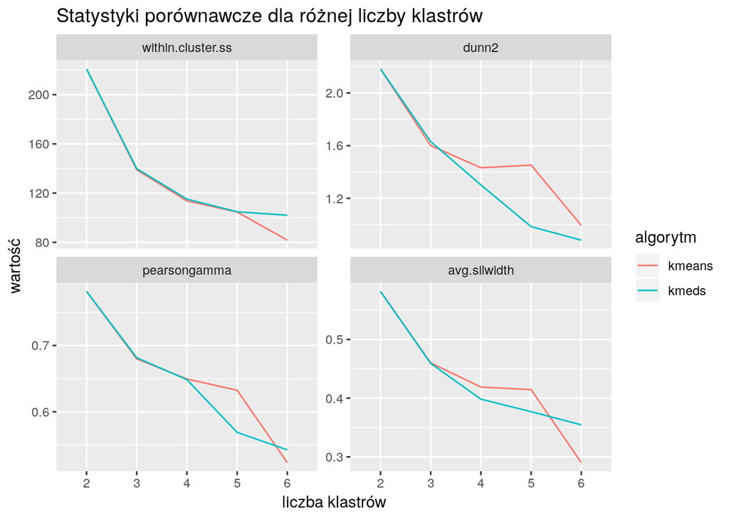

# 3 Porównanie klastrów

Porównamy teraz otrzymane wyniki dla dwóch i trzech klastrów. W drugim przypadku wykorzystamy oryginalne etykiety jako punkt odniesienia.

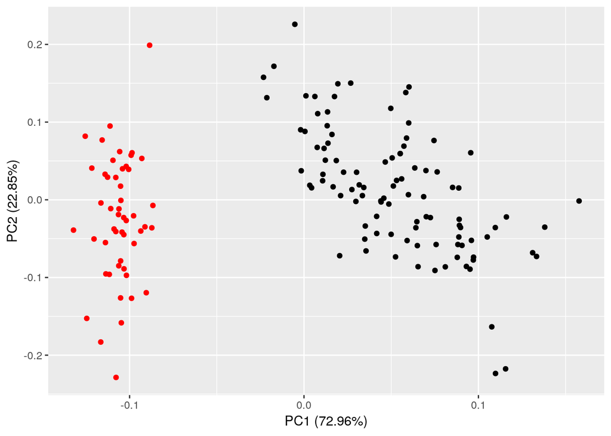

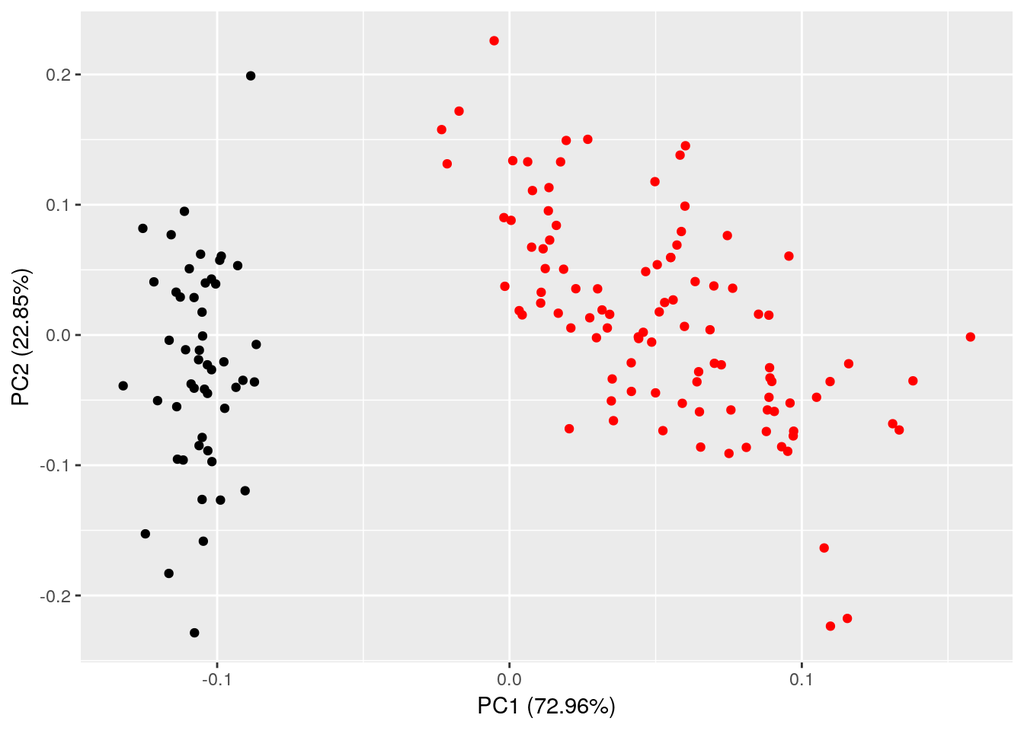

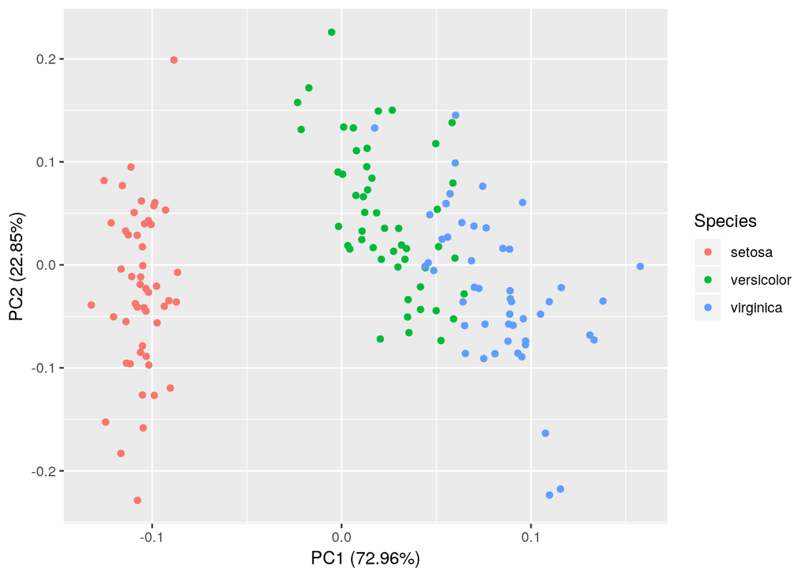

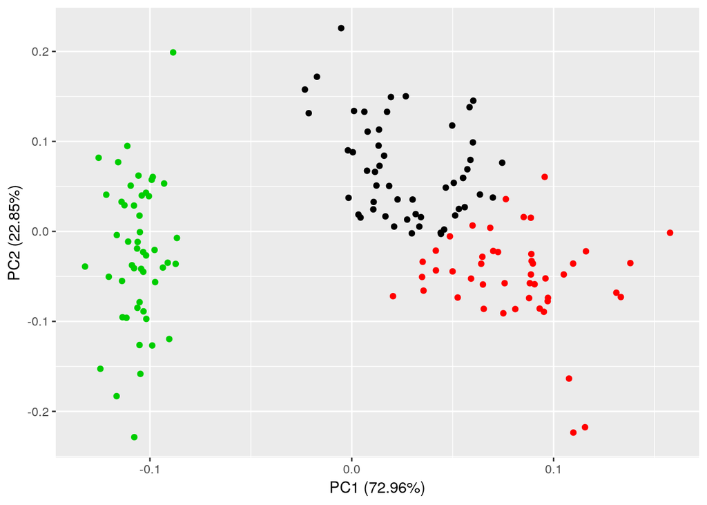

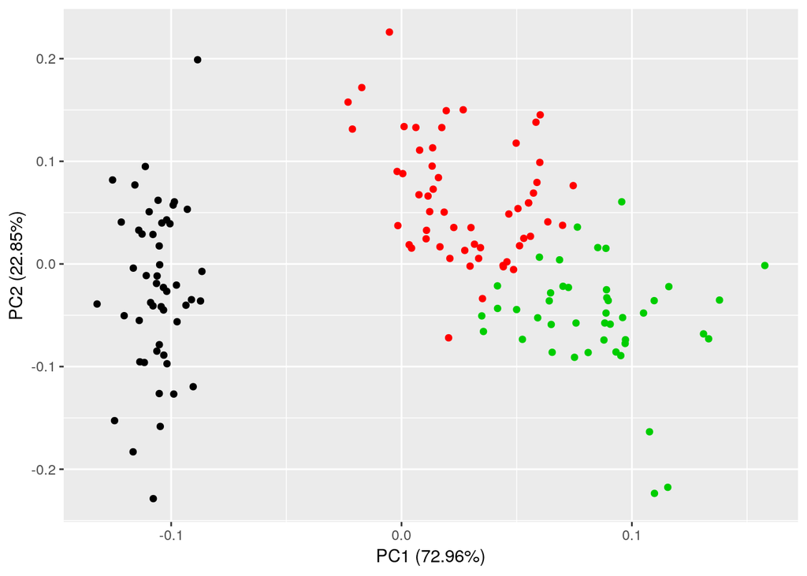

Widzimy, że różnice w podziałach stworzonych przez oba algorytmy są nieznaczne i ograniczają się do kilku granicznych punktów. Przypominają one rzeczywisty podział obserwacji, jednak różnią się od niego w pobiżu podziału międy odmianami versicolor i virginica, gdyż nie jest on tak regularny.

# 4 Centra klastrów

Porównamy centra klastrów wyznaczonych przez algorytmu. Są one główną różnicą między algorytmami, gdyż kmeds jako centrum klastra zawsze wybiera rzeczywistą obserwację ze zbioru.

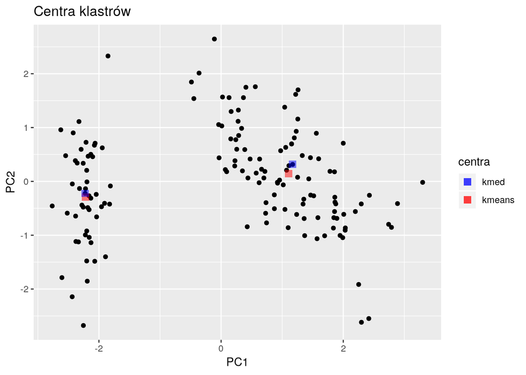

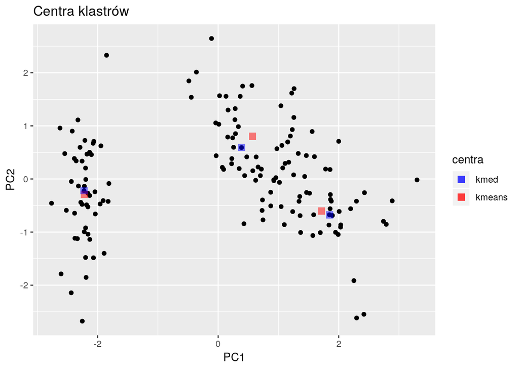

Widzimy, że centra znajdują się dość blisko siebie. Największą różnicę widać przy podziale na 3 klastry, w punktach odpowiadających odmianie versicolor. Algorytm k średnich jako centrum wskazał punkt będący zauważalnie oddalonym od istniejących obserwacji.

# 5 Czas wykonywania

Ponieważ wykorzystana implementacja algorytmu k medioidów nie zwraca liczby wykonanych iteracji, jesteśmy zmuszeni ograniczyć się do czasu wykonania algorytmu.

```
## Unit: microseconds
##    expr      min        lq      mean   median       uq      max neval
##  kmeans  202.328  232.3795  282.8444  260.989  300.924  618.400   100
##    kmed 3012.450 3178.0880 3586.4432 3297.686 3610.053 7480.534   100
```

Z wyników widać, że implementacja algorytmu k medioidów pomimo nazwy jest znacznie wolniejsza od k średnich.